# Static Data Visualization Gallery

March 2023

> This is a sample collection of non-interactive data visualizations. See the code used to develop these visualizations on [GitHub](https://github.com/toylyol/misc-data-viz/blob/main/Data%20Viz%20Gallery/DataVisualizationGallery.Rmd). R Markdown was used to create this gallery; the next iteration will, hopefully, be built using Quarto.

**California, Oregon, and Nevada saw the largest decrease in uninsured persons after the Affordable Care Act.**

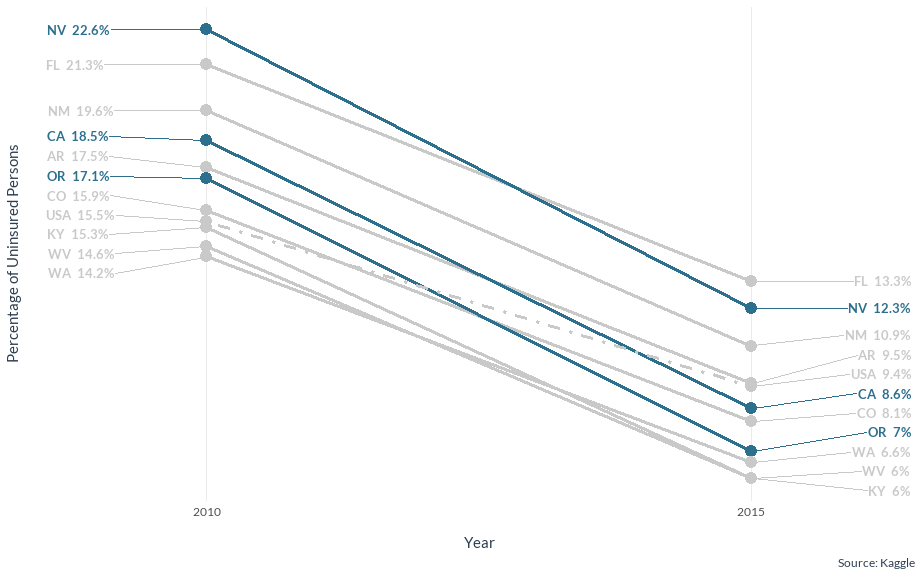

- Thanks to Bruno Kenzo for [inspiration](https://github.com/KenzoBH/Visualizations) on how to display this collection of data visualizations.
- The alt text was generated using the formula provided by Liz Hare in her October 2022 [presentation](https://lizharedogs.github.io/RLadiesNYAltText) for R-Ladies NYC.
- The data used in this slopegraph was downloaded from [Kaggle](https://www.kaggle.com/datasets/hhs/health-insurance).
- Chuck Powell’s [slopegraph tutorial](https://ibecav.github.io/slopegraph/) was invaluable.
- This [Stack Overflow forum](https://stackoverflow.com/questions/71573377/cannot-import-fonts-into-r) provided a quick way to load and use Google fonts without downloading them locally.
- The [Thinking on Data](https://www.thinkingondata.com/something-about-viridis-library/) blog provided the HEX codes in the viridis palette so that a cohesive color palette could be created.
- Many resources were used to remember the options that can be used for customization:
  - [Removing gridlines](https://r-graphics.org/recipe-appearance-hide-gridlines)
  - [Aligning captions](https://stackoverflow.com/questions/64701500/left-align-ggplot-caption)
  - [Changing geom_text_repel conditionally](https://stackoverflow.com/questions/49622822/control-colour-of-geom-text-repel)
  - [Specifying custom color scale](https://community.rstudio.com/t/setting-colours-in-ggplot-conditional-on-value/8328/2)
  - [Changing line types conditionally](http://www.sthda.com/english/wiki/ggplot2-line-types-how-to-change-line-types-of-a-graph-in-r-software)
  - [Aligning to the plot](https://ggplot2.tidyverse.org/articles/faq-axes.html#how-can-i-remove-the-space-between-the-plot-and-the-axis)

**In 2021, the counties of “Silicon Slopes” had some the highest percentages of teleworkers in Utah.**

Unsurprisingly, the three counties (Salt Lake, Summit, and Utah) comprising UT’s technology hub were among the top five counties with the highest percentage of teleworkers.

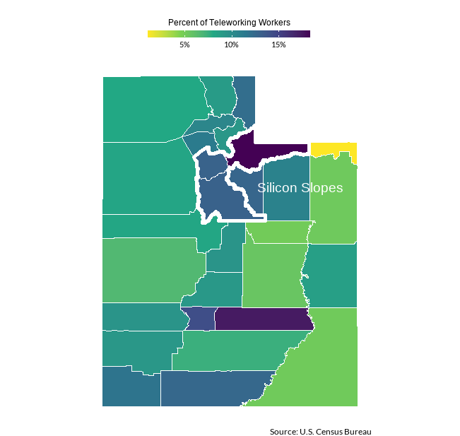

- The telework data were obtained from the U.S. Census Bureau’s [ACCESS BROADBAND Dashboard](https://www.census.gov/programs-surveys/community-resilience-estimates/partnerships/ntia/broadband-act.html). This dashboard is a result of work done by the Census Bureau and the National Telecommunications and Information Administration (NTIA) following the passage of the ACCESS BROADBAND Act of 2021. The original source of the telework data was the 2017-21 five-year American Community Survey.
- In the ACCESS Dashboard data dictionary, the definition for the percentage of teleworkers is as follows: “The percentage of workers ages 16 years and older that reported their residential address as the geographic location at which they carried out their occupational activities.” See the complete data dictionary online or in “/data/file_layout_ACCESS_BROADBAND_Dashboard.xlsx” within the R project on GitHub.
- [*Geomcomputation with R*](https://bookdown.org/robinlovelace/geocompr/geometric-operations.html) was helpful for learning which functions could be used to subset an existing shapefile, and union the resulting shapefiles, to create a new shapefile.

**McDonald’s ‘Big Breakfast’ is a high-cholesterol start to the day.**

Of the breakfast items listed, the Big Breakfast (with or without hotcakes) has the worst nutritional value.

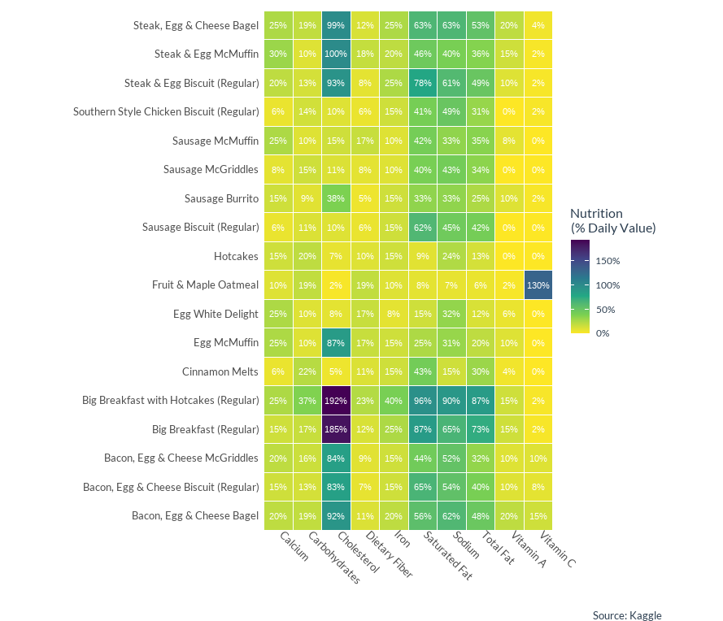

- The data visualized in this heatmap are from [Kaggle](https://www.kaggle.com/code/kathakaliseth/mcdonald-s-menu-comparative-nutrition-values).
- This Data Science Tutorials [heatmap tutorial](https://www.r-bloggers.com/2022/10/how-to-create-a-heatmap-in-r/) distributed via R-Bloggers were quite helpful for recalling how the data must be structured for a heatmap made with geom_tile().
- The code for a beautifully formatted horizontal colorbar is courtesy of Cédric Scherer’s [workshop materials](https://www.cedricscherer.com/slides/OutlierConf2021_ggplot-wizardry.pdf) from Data Visualization Society’s Outlier Conf 2021.
- Two Stack Overflow forums (1 and [2](https://stackoverflow.com/questions/23897175/adjust-ggplot2-geom-tile-height-and-width)) were helpful in ensuring the tiles were large enough were saved as a PNG.

**In, 2018 Oklahoma had the highest prevalence of elderly, female Medicare enrollees with 6+ chronic conditions.**

The prevalence of six or more chronic conditions among Medicare beneficiaries assigned female at birth aged 65 years or older was 20.5% in OK in 2018.

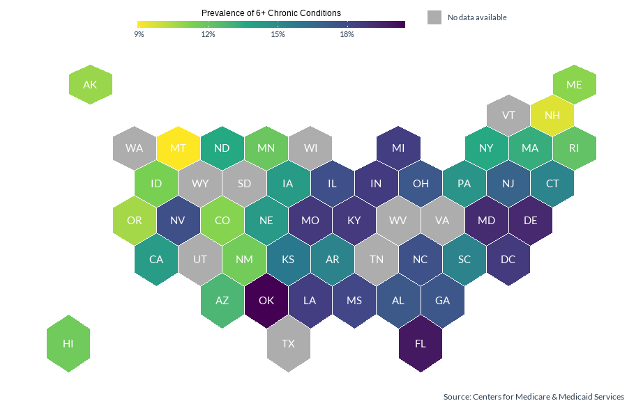

- This visualization is a hexbin map of the United States; it features data from the Centers for Medicare and Medicaid Services’ (CMS) Multiple Chronic Conditions (MCC) [dataset](https://data.cms.gov/medicare-chronic-conditions/multiple-chronic-conditions).
- The MCC data were retrieved through the CMS [API](https://data.cms.gov/api-docs). More information about the dataset can be viewed in the [data dictionary](https://data.cms.gov/resources/multiple-chronic-conditions-data-dictionary) and [methodology documentation](https://data.cms.gov/resources/medicare-chronic-conditions-methodology).
- Yan Holtz’s excellent [hexbin map tutorial](https://r-graph-gallery.com/328-hexbin-map-of-the-usa.html) on The R Graph Gallery provided the data source for the hexagonal shapefile—as well as helpful hints for manipulating the file.
- The hexagonal shapefile of the United States was obtained from [Carto](https://team.carto.com/u/andrew/tables/andrew.us_states_hexgrid/public/map). It can be downloaded in other formats, such as GeoJSON.
- Tips and tricks for handling NA values in a continuous choropleth map were learned from R for the Rest of Us’ [Mapping with R](https://rfortherestofus.com/courses/mapping/) taught by Charlie Hadley.

Toyin L. Ola